# RaySolver

| **Model** | `AcousticRayTracers.RaySolver` |
| --- | --- |
| **Description** | 2½D acoustic Gaussian beam tracer |
| **Language** | Julia |
| **Advantages** | Differentiable (forward mode) |
| **Limitations** | Tell us and we will fix them! |
| **Differentiability** | `ForwardDiff` |

```
RaySolver(env; kwargs...)
```

Julia implementation of a ray/Gaussian beam propagation model. The model supports complex environments, but retains differentiability.

Supported keyword arguments:

- `nbeams`: number of beams to use (default: 0, auto)
- `min_angle`: minimum beam angle (default: -80°)
- `max_angle`: maximum beam angle (default: 80°)
- `ds`: nominal spacing between ray points (default: 1/10 water depth)
- `atol`: absolute position tolerance (default: 0.0001 m)
- `rugosity`: TODO (default: 1.5)
- `min_amplitude`: minimum ray amplitude to track (default: 1e-6); rays weaker than this (including absorption) stop being traced, which also culls weak multipath from `arrivals` — set to `0.0` to keep all arrivals (e.g. for impulse-response work)
- `solver`: differential equation solver (default: nothing, auto)
- `solver_tol`: solver tolerance (default: 1e-8)
- `backscatter`: continue tracing rays that turn back toward the source (default: false)
- `rmin`: left edge of modeling domain in m, ≤ 0 (default: 0; only meaningful with backscatter)
- `rmax`: right edge of modeling domain in m (default: 0, auto = query range)
- `ntasks`: number of parallel tasks to use (default: 0, auto = number of threads; 1 = serial, useful for benchmarking and for AD tools that dislike threads)

If the environment contains scatterers (`env.scatterers`), rays reflect off them using the scatterer’s boundary condition. With `backscatter` enabled, rays are traced until they exit the modeling domain `r ∈ [rmin, rmax]` or become too weak (`min_amplitude`, including absorption); backscattered arrivals are reported with |arrival angle| > π/2. Features outside the modeling domain are invisible; set `rmax` beyond the query range to capture echoes from behind the receivers. If `rmin < 0`, a second fan of rays with the same elevation angles is launched in the -x direction, so that features to the left of the transmitter can also produce echoes (such arrivals have |launch angle| > π/2).

`RaySolver` is a differentiable 2½D Gaussian beam tracer similar to [Bellhop](http://oalib.hlsresearch.com/AcousticsToolbox/), but fully written in Julia to be compatible with automatic differentiation (AD) tools such as `ForwardDiff`. Its implementation is largely based on the description in:

- Jensen, Kuperman, Porter & Schmidt, “Computational Ocean Acoustics,” Springer New York, NY, 2011.

## Example

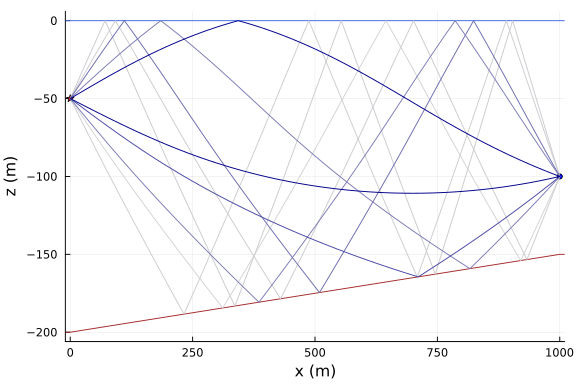

```julia
using UnderwaterAcoustics
using AcousticRayTracers
using Plots

env = UnderwaterEnvironment(
  bathymetry = SampledField([200, 150]; x=[0, 1000], interp=Linear()),
  soundspeed = SampledField([1500, 1480, 1495, 1510, 1520]; z=0:-50:-200, interp=CubicSpline()),
  seabed = SandyClay
)
pm = RaySolver(env)

tx = AcousticSource(0, -50, 300)
rx = AcousticReceiver(1000, -100)
rays = arrivals(pm, tx, rx)

plot(env; xlims=(-10, 1010))
plot!(tx)
plot!(rx)
plot!(rays)
```

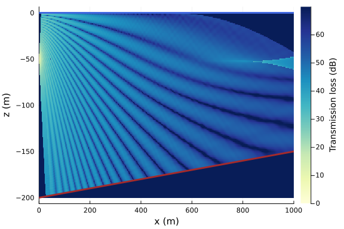

```julia
rxs = AcousticReceiverGrid2D(1:1000, -200:0)
x = transmission_loss(pm, tx, rxs; mode=:coherent)

plot(rxs, x; crange=70)
plot!(env; xlims=(0,1000), linewidth=3)
```

## Backscatter

By default, `RaySolver` terminates rays that turn around and head back toward the source. Enabling the `backscatter` option continues tracing such rays until they exit the modeling domain ($\texttt{rmin} ≤ x ≤ \texttt{rmax}$) or become too weak to matter (`min_amplitude`). This allows the model to predict echoes from steep bathymetric features. Backscattered eigenrays are reported with arrival angles $|θᵣ| > 90°$, and contribute to arrivals, acoustic fields and impulse responses.

If `rmax` is not specified, the modeling domain extends to the query range (the receiver range, or the far edge of a receiver grid) — the same domain as without backscatter. Anything beyond the domain is invisible to the model, so echoes from features behind the receivers require an explicit larger `rmax` (as in the example below, where the slope lies beyond the receiver). Setting `rmin < 0` extends the domain to the left of the transmitter; a second fan of rays with the same elevation angles is then automatically launched in the $-x$ direction, so that features to the left of the transmitter can also produce echoes (such arrivals have launch angles $|θₛ| > 90°$).

To illustrate, we place a transmitter and a receiver in a 200 m deep channel that ends in a steep rocky slope rising to 10 m depth. Rays travel past the receiver, reverse off the slope (via slope and surface bounce combinations), and return to the receiver from behind. We plot the strongest 3 forward and strongest 3 backscattered eigenrays:

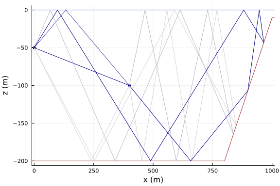

```julia
env = UnderwaterEnvironment(
  bathymetry = SampledField([200, 200, 10]; x=[0, 800, 1000], interp=Linear()),
  soundspeed = 1500,
  seabed = Rock
)
pm = RaySolver(env; backscatter=true, rmax=1000)

tx = AcousticSource(0, -50, 300)
rx = AcousticReceiver(400, -100)
rays = arrivals(pm, tx, rx)

fwd = filter(a -> abs(a.θᵣ) ≤ π/2, rays)        # forward eigenrays
echoes = filter(a -> abs(a.θᵣ) > π/2, rays)     # backscattered eigenrays
strongest(a, n) = sort(a; by = x -> abs(x.ϕ), rev=true)[1:min(n, length(a))]

plot(env; xlims=(-10, 1010))
plot!(tx)
plot!(rx)
plot!(strongest(fwd, 3))
plot!(strongest(echoes, 3))
```

## Scatterers (experimental)

`RaySolver` has experimental support for discrete scatterers in the water column, described in the environment with the `scatterers` field (see `Scatterer`). Rays reflect specularly off the scatterer boundary: the amplitude is given by the scatterer’s acoustic boundary condition via the standard reflection coefficient at the local tangent plane, and the Gaussian beam spreading is corrected for the curvature of the surface. Scatterer geometry may be differentiated through, i.e., gradients of acoustic quantities with respect to scatterer position and size are supported.

Scatterers are usually used together with `backscatter=true`, so that target echoes propagate back toward the source. Here, a small rigid ellipse on the transmitter–receiver line blocks the direct path, while a larger rigid ellipse, shallower and beyond the receiver, is rotated so that its face reflects the transmitter’s rays down to the receiver:

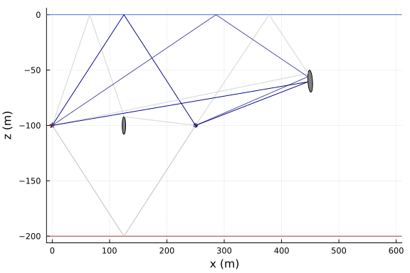

```julia
env = UnderwaterEnvironment(
  bathymetry = 200,
  soundspeed = 1500,
  seabed = SandyClay,
  scatterers = (
    Scatterer(Ellipse(125, -100, 8, 3; θ=90°), RigidBoundary),   # blocks the direct path
    Scatterer(Ellipse(450, -60, 10, 4; θ=-82°), RigidBoundary)   # reflects toward the receiver
  )
)
pm = RaySolver(env; backscatter=true, rmax=600, nbeams=2500)

tx = AcousticSource(0, -100, 1000)
rx = AcousticReceiver(250, -100)
rays = arrivals(pm, tx, rx)

fwd = filter(a -> abs(a.θᵣ) ≤ π/2, rays)
echoes = filter(a -> abs(a.θᵣ) > π/2, rays)

plot(env; xlims=(-10, 610))
plot!(tx)
plot!(rx)
plot!(strongest(fwd, 3))
plot!(strongest(echoes, 3))
```

There is no direct eigenray — every forward path detours around the blocking scatterer — and the strongest echoes arrive from the tilted reflector behind and above the receiver. The transmission loss field shows the geometric shadows cast by both targets, and the interference of the backscattered field with the outgoing field:

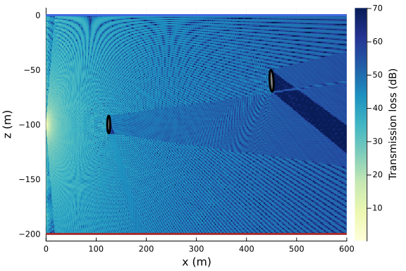

```julia
rxs = AcousticReceiverGrid2D(1:600, -200:0)
x = transmission_loss(pm, tx, rxs; mode=:coherent)

plot(rxs, x; crange=70)
plot!(env; xlims=(0,600), linewidth=3)
```

## Notes

The `RaySolver` propagation model requires that the transmitter is located at $(x=0, y=0)$ and all receivers are located in the right half-plane (i.e., $x>0$ and $y=0$). This limitation can be worked around by wrapping the model with `Reframe2D`, which automatically transforms 2D scenarios specified in world coordinates into the coordinate system required by the model (see the quickstart guide for an example).